# Streaming Services - Stock Price Analysis

## Checking For Linear Regression

We also added a LOESS smoother to visualize the regression line.

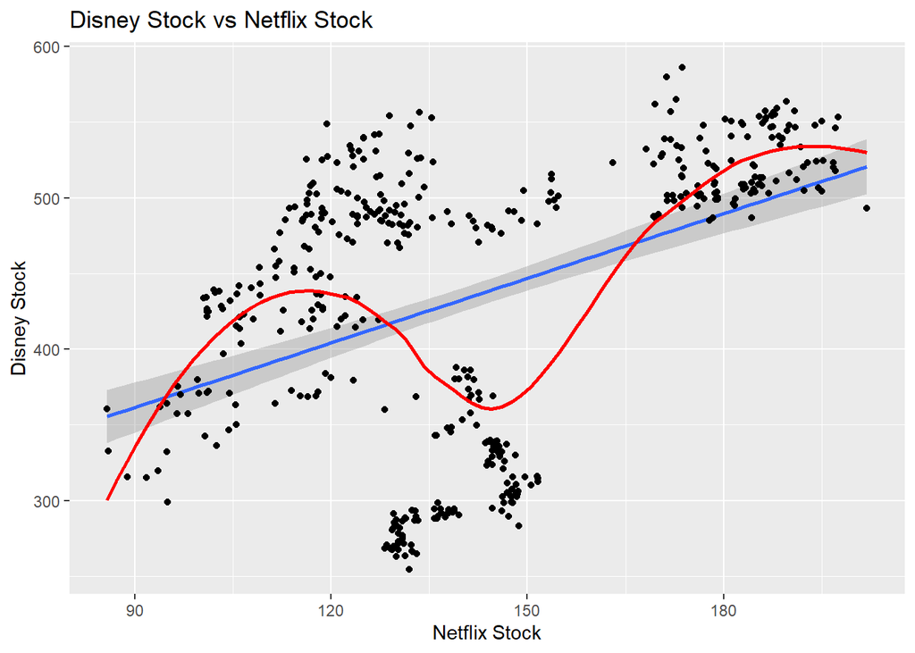

```r
disney <- stocks %>% filter(Date > as.Date('2019-09-01'))

disney %>% ggplot(aes(x = DIS.Close,
                      y = NFLX.Close)) +
  geom_smooth(method = 'lm') +
  geom_point() +
  geom_smooth(se = F,
              color = 'red') +
  labs(title = 'Disney Stock vs Netflix Stock',
       y = 'Disney Stock',
       x = 'Netflix Stock')
```

As you can see, this relationship is not linear. Actually unsurprising, it would have been extraordinary if Disney and Netflix stock prices were so closely correlated.

## Conclusions and Recommendations

Back in the day, Netflix used to rule the streaming services, since it was the pioneer or at least the on that had success. It provided 90% of what you actualy wanted to see, no comercials or interruptions, all what you wanted to see, whenever you wanted to see. Nowadays we’re seeing Netflix lose content to Disney+, Amazon and others, and eventually you will require a lot more than just one or two streaming services too see all your favorite shows and movies.

For this project we compared different methods to evaluate the success not just of the top 4 streaming services but the top hows they offer. Quantmod helped us to gather stock prices, which are a good indicator of the path companies have had. We also used Google Trends to get to know the popularity of the shows and its distribution among the Us population. These two data sets gaves a general overview of the streaming companies.